# Final Charity Project

Priyanka G , Andrei R, Tyler K

January 28, 2018

#### Problem Statement

A charitable organization wishes to develop a **machine learning model to improve the cost-effectiveness of their direct marketing campaigns** to previous donors. According to their recent mailing records, the typical overall response rate is 10%. Out of those who respond (donate) to the mailing, the average donation is 14.50. Each mailing costs 2.00 to produce and send; the mailing includes a gift of personalized address labels and assortment of cards and envelopes. It is not cost-effective to mail everyone because the expected profit from each mailing is 14.50 x 0.10 – 2 = -$0.55.

We would like to **develop a classification model** using data from the most recent campaign that can effectively captures likely donors so that the expected net profit is maximized. The response rate in the test sample has the more typical 10% response rate.

We would also like to **build a prediction model** to predict expected gift amounts from donors – the data for this will consist of the records for donors only.

**End Goal: Maximize the profits (expected revenue less the costs) on the marketing campaign**

#### Data

The entire dataset consists of *3984 training* observations, *2018 validation* observations, and *2007 test* observations. Weighted sampling has been used, over-representing the responders so that the training and validation samples have approximately equal numbers of donors and non-donors.

#### Data Exploration

```r
# load the data
# charity <- read.csv(file.choose()) # load the "charity.csv" file
charity <- read.csv("D:/Boston College/MS AE Courses/Spring 2018 - Big Data Econometrics/Projects/Final Group Project/charity.csv")

library(psych)
describe(charity)
```

```
##       vars    n    mean      sd  median trimmed     mad   min     max
## ID       1 8009 4005.00 2312.14 4005.00 4005.00 2968.17  1.00 8009.00
## reg1     2 8009    0.20    0.40    0.00    0.13    0.00  0.00    1.00
## reg2     3 8009    0.32    0.47    0.00    0.27    0.00  0.00    1.00
## reg3     4 8009    0.13    0.34    0.00    0.04    0.00  0.00    1.00
## reg4     5 8009    0.14    0.35    0.00    0.05    0.00  0.00    1.00
## home     6 8009    0.87    0.34    1.00    0.96    0.00  0.00    1.00
## chld     7 8009    1.72    1.40    2.00    1.61    1.48  0.00    5.00
## hinc     8 8009    3.91    1.47    4.00    3.89    1.48  1.00    7.00
## genf     9 8009    0.61    0.49    1.00    0.63    0.00  0.00    1.00
## wrat    10 8009    6.91    2.43    8.00    7.35    1.48  0.00    9.00
## avhv    11 8009  182.65   72.72  169.00  174.55   59.30 48.00  710.00
## incm    12 8009   43.47   24.71   38.00   40.19   19.27  3.00  287.00
## inca    13 8009   56.43   24.82   51.00   53.46   19.27 12.00  305.00
## plow    14 8009   14.23   13.41   10.00   12.24   11.86  0.00   87.00
## npro    15 8009   60.03   30.35   58.00   58.88   34.10  2.00  164.00
## tgif    16 8009  113.07   85.48   89.00   99.77   47.44 23.00 2057.00
## lgif    17 8009   22.94   29.95   16.00   17.43   10.38  3.00  681.00
## rgif    18 8009   15.66   12.43   12.00   13.66    8.90  1.00  173.00
## tdon    19 8009   18.86    5.78   18.00   18.31    4.45  5.00   40.00
## tlag    20 8009    6.36    3.70    5.00    5.70    2.97  1.00   34.00
## agif    21 8009   11.68    6.57   10.23   10.83    5.50  1.29   72.27
## donr    22 6002    0.50    0.50    0.00    0.50    0.00  0.00    1.00
## damt    23 6002    7.21    7.36    0.00    6.85    0.00  0.00   27.00
## part*   24 8009    2.00    0.71    2.00    2.00    1.48  1.00    3.00
##         range  skew kurtosis    se
## ID    8008.00  0.00    -1.20 25.84
## reg1     1.00  1.50     0.24  0.00
## reg2     1.00  0.78    -1.40  0.01
## reg3     1.00  2.15     2.63  0.00
## reg4     1.00  2.08     2.33  0.00
## home     1.00 -2.16     2.64  0.00
## chld     5.00  0.27    -0.80  0.02
## hinc     6.00  0.01    -0.09  0.02
## genf     1.00 -0.43    -1.81  0.01
## wrat     9.00 -1.35     0.79  0.03
## avhv   662.00  1.54     4.49  0.81
## incm   284.00  2.05     8.31  0.28
## inca   293.00  1.94     7.87  0.28
## plow    87.00  1.36     1.89  0.15
## npro   162.00  0.31    -0.62  0.34
## tgif  2034.00  6.55   107.52  0.96
## lgif   678.00  7.81   110.38  0.33
## rgif   172.00  2.63    13.92  0.14
## tdon    35.00  1.10     2.12  0.06
## tlag    33.00  2.42     8.41  0.04
## agif    70.98  1.78     6.02  0.07
## donr     1.00  0.00    -2.00  0.01
## damt    27.00  0.12    -1.83  0.10
## part*    2.00  0.00    -1.01  0.01
```

```r
# describe(log(charity$tdon))

colSums(sapply(charity, is.na))
```

```
##   ID reg1 reg2 reg3 reg4 home chld hinc genf wrat avhv incm inca plow npro
##    0    0    0    0    0    0    0    0    0    0    0    0    0    0    0
## tgif lgif rgif tdon tlag agif donr damt part
##    0    0    0    0    0    0 2007 2007    0
```

- **Categorical** : REG1, REG2, REG3, REG4[4 dummy variables for 5 geographic regions], home[home ownder or not], wrat[wealth ratings 0-9], HINC[household income 1-7], GENF[gender]
- **Numeric** : CHLD, AVHV, INCM, INCA, PLOW, NPRO, TGIF, LGIF, RGIF, TDON, TLAG, AGIF.

```r
#summary(charity[charity$part=="train",])
charity.train <- charity[charity$part=="train",]

cat_Vars<-c("wrat","reg1","reg2","reg3","reg4","chld","home","genf","donr")
fact_Vars<-c("ID","wrat","reg1","reg2","reg3","reg4","chld","home","genf","donr","part")

library(pastecs)
stat.desc(charity.train[,!(colnames(charity) %in% fact_Vars)], basic = FALSE, norm = TRUE)
```

```
##                       hinc         avhv         incm         inca
## median        4.000000e+00 1.710000e+02 3.900000e+01 5.200000e+01
## mean          3.946285e+00 1.851842e+02 4.428840e+01 5.713554e+01
## SE.mean       2.213459e-02 1.183481e+00 3.988590e-01 4.004511e-01
## CI.mean.0.95  4.339619e-02 2.320286e+00 7.819869e-01 7.851082e-01
## var           1.951922e+00 5.580102e+03 6.338086e+02 6.388784e+02
## std.dev       1.397112e+00 7.470008e+01 2.517556e+01 2.527604e+01
## coef.var      3.540322e-01 4.033825e-01 5.684458e-01 4.423874e-01
## skewness     -9.722617e-04 1.547448e+00 1.999558e+00 1.866605e+00
## skew.2SE     -1.253143e-02 1.994497e+01 2.577219e+01 2.405857e+01
## kurtosis      1.278076e-01 4.368741e+00 8.100369e+00 6.950879e+00
## kurt.2SE      8.238593e-01 2.816129e+01 5.221570e+01 4.480598e+01
## normtest.W    9.131411e-01 9.015639e-01 8.610426e-01 8.762568e-01
## normtest.p    5.278763e-43 5.628907e-45 1.199436e-50 1.060381e-48
##                      plow          npro         tgif         lgif
## median       1.000000e+01  6.000000e+01 9.100000e+01 1.500000e+01
## mean         1.373268e+01  6.162927e+01 1.167447e+02 2.319302e+01
## SE.mean      2.074478e-01  4.806751e-01 1.353938e+00 4.955428e-01
## CI.mean.0.95 4.067137e-01  9.423923e-01 2.654476e+00 9.715412e-01
## var          1.714497e+02  9.204975e+02 7.303260e+03 9.783215e+02
## std.dev      1.309388e+01  3.033970e+01 8.545911e+01 3.127813e+01
## coef.var     9.534833e-01  4.922937e-01 7.320169e-01 1.348601e+00
## skewness     1.380889e+00  2.794947e-01 5.051670e+00 7.870416e+00
## skew.2SE     1.779820e+01  3.602393e+00 6.511071e+01 1.014414e+02
## kurtosis     1.933290e+00 -6.152998e-01 7.028005e+01 1.053568e+02
## kurt.2SE     1.246216e+01 -3.966277e+00 4.530314e+02 6.791391e+02
## normtest.W   8.686586e-01  9.814236e-01 7.040989e-01 4.608955e-01
## normtest.p   1.071742e-49  1.847981e-22 2.654817e-64 2.469441e-76
##                      rgif         tdon         tlag         agif
## median       1.200000e+01 1.800000e+01 5.000000e+00 1.022000e+01
## mean         1.554669e+01 1.881476e+01 6.301958e+00 1.165924e+01
## SE.mean      1.913403e-01 8.844124e-02 5.700427e-02 1.015743e-01
## CI.mean.0.95 3.751342e-01 1.733943e-01 1.117603e-01 1.991425e-01
## var          1.458587e+02 3.116226e+01 1.294596e+01 4.110429e+01
## std.dev      1.207720e+01 5.582317e+00 3.598049e+00 6.411263e+00
## coef.var     7.768342e-01 2.966988e-01 5.709415e-01 5.498869e-01
## skewness     2.652387e+00 1.126548e+00 2.414226e+00 1.643531e+00
## skew.2SE     3.418647e+01 1.452002e+01 3.111683e+01 2.118338e+01
## kurtosis     1.569152e+01 2.422921e+00 8.450899e+00 4.949063e+00
## kurt.2SE     1.011489e+02 1.561836e+01 5.447524e+01 3.190210e+01
## normtest.W   7.988907e-01 9.229075e-01 7.721709e-01 8.843321e-01
## normtest.p   4.074392e-57 3.628989e-41 2.170872e-59 1.380742e-47
##                       damt
## median        1.000000e+01
## mean          7.260040e+00
## SE.mean       1.168954e-01
## CI.mean.0.95  2.291804e-01
## var           5.443952e+01
## std.dev       7.378314e+00
## coef.var      1.016291e+00
## skewness      1.026073e-01
## skew.2SE      1.322500e+00
## kurtosis     -1.844542e+00
## kurt.2SE     -1.189008e+01
## normtest.W    7.412550e-01
## normtest.p    9.344744e-62
```

The two parameters skew.2se and kurt.2se results, which are the skew and kurtosis value divided by 2 standard errors. If the absolute value of these parameters are > 1 then they are significant (at p < .05) suggesting strong potential for non-normality.

```r
library(purrr)
library(tidyr)
```

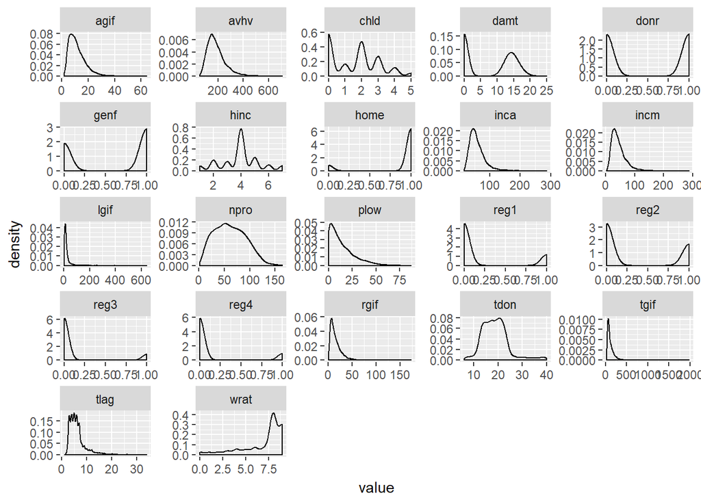

```r
library(ggplot2)
# DENSITY PLOTS TO CHECK NORMALITY OF NUMERIC VARIABLES

charity.train[,-1] %>%
  keep(is.numeric) %>%
  gather() %>%
ggplot(aes(value)) +
#   stat_density() +   # Fills in the density graph/area.
    facet_wrap(~ key, scales = "free") +
    geom_density()
```

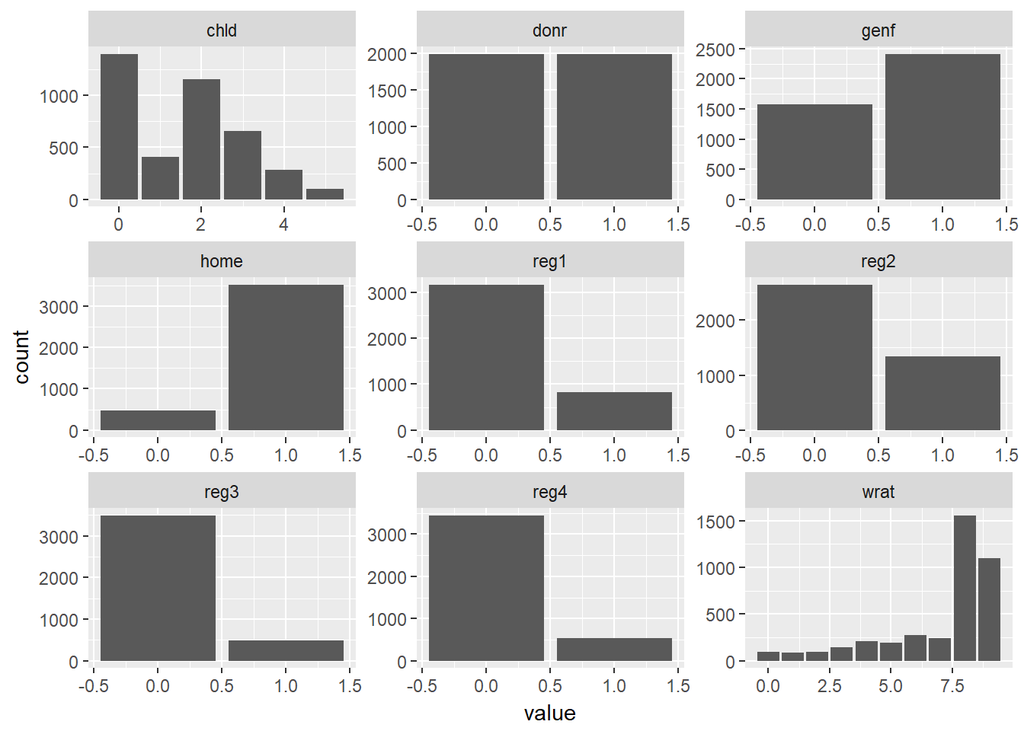

```r
# BAR GRAPHS TO CHECK THE BALANCE OF CATEGORICAL/FACTOR VARIABLES

charity.train[,cat_Vars] %>%
    gather() %>%
ggplot(aes(value)) +
    facet_wrap(~key, scales = "free") +
    geom_bar()
```

```r
# ggplot(charity.train, aes(donr)) +
#     facet_grid(genf~.)
#     geom_bar(stat="identity")
```

Lets try to answer some questions:

- 1. Viewing the distribution: is it normal?

The `npro`, `tdon` variables are closest to normal. This means most of our data will need to be transformed.

- 2. Identifying the skewness

We can see that `agif`,`avhv`,`home`,`inca`,`incm`, `lgif`, `plow` ,`rgif`,`tgif` ,`tlag` and `wrat` are highly skewed. Several other variables have moderate skewness.

- 3. Identifying the outliers

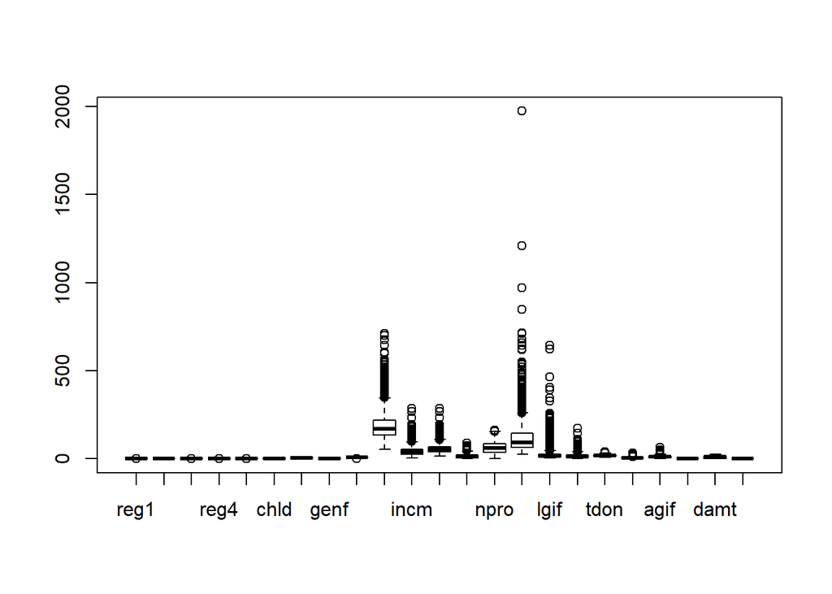

```r
boxplot(charity.train[-1])
```

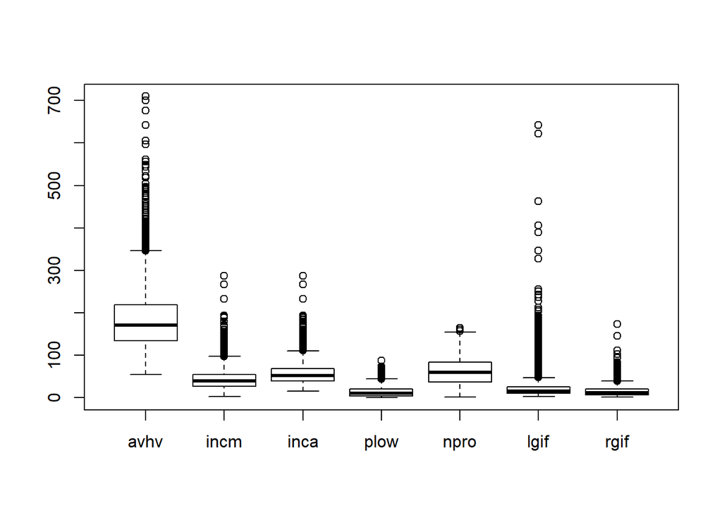

```r
oth_Vars<- c("hinc","tgif","agif","tlag","tdon","damt")
outl<-names(charity.train) %in% c(fact_Vars,oth_Vars)
boxplot(charity.train[!outl])
```

The variables in this 2nd boxplot may need to be treated for outliers.

#### Data Pre Processing

Lets pre-processing the data based on their behaviour as learned in exploration section above.

```r
# predictor transformations
# charity.t <- charity
# charity.t$avhv <- log(charity.t$avhv)

# boxplot(charity.t$avhv)
```

```r
# set up data for analysis

data.train <- charity.train
x.train <- data.train[,2:21]
y.train.donr <- data.train[,22] # donr
y.train.damt <- data.train[y.train.donr==1,23] # damt for observations with donr=1
# y.train.damt <- data.train["donr"==1,23] # damt for observations with donr=1
n.train.donr <- length(y.train.donr) # 3984
n.train.damt <- length(y.train.damt) # 1995

data.valid <- charity[charity$part=="valid",]
x.valid <- data.valid[,2:21]
y.valid.donr <- data.valid[,22] # donr
y.valid.damt <- data.valid[y.valid.donr==1,23] # damt for observations with donr=1
n.valid.donr <- length(y.valid.donr) # 2018
n.valid.damt <- length(y.valid.damt) # 999

data.test <- charity[charity$part=="test",]
n.test <- dim(data.test)[1] # 2007
x.test <- data.test[,2:21]


# standardize to have zero mean and unit sd

x.train.mean <- apply(x.train, 2, mean)
x.train.sd <- apply(x.train, 2, sd)

# performing the standardization at this step

x.train.std <- t((t(x.train)-x.train.mean)/x.train.sd)
apply(x.train.std, 2, mean) # check zero mean
```

```
##          reg1          reg2          reg3          reg4          home
##  2.151811e-17 -2.526099e-17  3.693258e-17 -6.017778e-17 -9.663428e-18
##          chld          hinc          genf          wrat          avhv
## -2.051129e-17 -1.463197e-17  4.465563e-17 -1.062688e-16  1.816327e-17
##          incm          inca          plow          npro          tgif
## -1.335981e-16  8.260581e-17  4.848389e-17 -6.655491e-17  2.532023e-17
##          lgif          rgif          tdon          tlag          agif
##  2.669731e-17  5.429393e-18 -1.835154e-16  1.010477e-16 -1.258480e-16
```

```r
apply(x.train.std, 2, sd) # check unit sd
```

```
## reg1 reg2 reg3 reg4 home chld hinc genf wrat avhv incm inca plow npro tgif
##    1    1    1    1    1    1    1    1    1    1    1    1    1    1    1
## lgif rgif tdon tlag agif
##    1    1    1    1    1
```

```r
data.train.std.donr <- data.frame(x.train.std, donr=y.train.donr) # to classify donr
data.train.std.damt <- data.frame(x.train.std[y.train.donr==1,], damt=y.train.damt) # to predict damt when donr=1

x.valid.std <- t((t(x.valid)-x.train.mean)/x.train.sd) # standardize using training mean and sd
data.valid.std.donr <- data.frame(x.valid.std, donr=y.valid.donr) # to classify donr
data.valid.std.damt <- data.frame(x.valid.std[y.valid.donr==1,], damt=y.valid.damt) # to predict damt when donr=1

x.test.std <- t((t(x.test)-x.train.mean)/x.train.sd) # standardize using training mean and sd
data.test.std <- data.frame(x.test.std)
```

We have seperated the train, validation and test datasets. We also standardized all of the column fields to avoid the scaling issues affecting some statistical methods.

#### FEATURE ENGINEERING/ VARIABLE SELECTION

Before actually starting to model. A quick look at identifying significant variables here.

```r
cor(data.train.std.donr[, !(colnames(data.train.std.donr) %in% fact_Vars)])
```

```
##              hinc         avhv         incm          inca         plow
## hinc  1.000000000  0.017689974  0.012054151  0.0131884781 -0.006398353
## avhv  0.017689974  1.000000000  0.722519341  0.8408769868 -0.625136632
## incm  0.012054151  0.722519341  1.000000000  0.8729018527 -0.655455152
## inca  0.013188478  0.840876987  0.872901853  1.0000000000 -0.634632891
## plow -0.006398353 -0.625136632 -0.655455152 -0.6346328906  1.000000000
## npro  0.023097994 -0.002658239  0.017073640  0.0182656423 -0.011667686
## tgif  0.011496846  0.018886905  0.041677073  0.0354444121 -0.017615631
## lgif -0.009139114 -0.011299427  0.006731373 -0.0075395084  0.005928332
## rgif -0.002380876 -0.003325955  0.002748777 -0.0053741219 -0.013643922
## tdon  0.014723148 -0.008495970 -0.013859730 -0.0162847340  0.016682061
## tlag -0.030735162 -0.004848666 -0.021305788 -0.0169451119  0.021362168
## agif -0.004664742 -0.002257410  0.010328347 -0.0001531168 -0.013683353
##               npro        tgif         lgif         rgif          tdon
## hinc  0.0230979942  0.01149685 -0.009139114 -0.002380876  0.0147231478
## avhv -0.0026582392  0.01888690 -0.011299427 -0.003325955 -0.0084959698
## incm  0.0170736403  0.04167707  0.006731373  0.002748777 -0.0138597299
## inca  0.0182656423  0.03544441 -0.007539508 -0.005374122 -0.0162847340
## plow -0.0116676863 -0.01761563  0.005928332 -0.013643922  0.0166820612
## npro  1.0000000000  0.72664798 -0.001328901 -0.012489364  0.0009863842
## tgif  0.7266479833  1.00000000  0.173434853  0.073608064 -0.0113031199
## lgif -0.0013289011  0.17343485  1.000000000  0.696059825  0.0036342686
## rgif -0.0124893642  0.07360806  0.696059825  1.000000000  0.0063324838
## tdon  0.0009863842 -0.01130312  0.003634269  0.006332484  1.0000000000
## tlag  0.0057474624 -0.01172427  0.016816132  0.012158261 -0.0061519123
## agif  0.0022454370  0.05577226  0.609630157  0.705341391  0.0079658768
##              tlag          agif
## hinc -0.030735162 -0.0046647419
## avhv -0.004848666 -0.0022574096
## incm -0.021305788  0.0103283470
## inca -0.016945112 -0.0001531168
## plow  0.021362168 -0.0136833534
## npro  0.005747462  0.0022454370
## tgif -0.011724267  0.0557722567
## lgif  0.016816132  0.6096301573
## rgif  0.012158261  0.7053413905
## tdon -0.006151912  0.0079658768
## tlag  1.000000000  0.0299336658
## agif  0.029933666  1.0000000000
```

```r
cor(data.train.std.donr[,c("incm","inca","plow")])
```

```
##            incm       inca       plow
## incm  1.0000000  0.8729019 -0.6554552
## inca  0.8729019  1.0000000 -0.6346329
## plow -0.6554552 -0.6346329  1.0000000
```

```r
cor(data.train.std.donr[,c("npro","tgif")])
```

```
##          npro     tgif
## npro 1.000000 0.726648
## tgif 0.726648 1.000000
```

```r
cor(data.train.std.donr[,c("lgif","rgif","agif")])
```

```
##           lgif      rgif      agif
## lgif 1.0000000 0.6960598 0.6096302
## rgif 0.6960598 1.0000000 0.7053414
## agif 0.6096302 0.7053414 1.0000000
```

We see that, as expected, there are high correlations in `inca`,`incm` and `plow` ; and similarly high correlation between `npro` and `tgif`; between `lgif`, `rgif` and `agif`.

```r
chk<-lm(damt~.,data=data.train.std.damt)
summary(chk)
```

```
##
## Call:
## lm(formula = damt ~ ., data = data.train.std.damt)
##
## Residuals:
##     Min      1Q  Median      3Q     Max
## -4.4624 -0.7966 -0.1533  0.5999  9.1086
##
## Coefficients:
##             Estimate Std. Error t value Pr(>|t|)
## (Intercept) 14.18934    0.04735 299.660  < 2e-16 ***
## reg1        -0.03923    0.03962  -0.990  0.32217
## reg2        -0.07434    0.04294  -1.731  0.08352 .
## reg3         0.32690    0.04041   8.089 1.04e-15 ***
## reg4         0.63517    0.04158  15.275  < 2e-16 ***
## home         0.23834    0.06073   3.925 8.99e-05 ***
## chld        -0.60477    0.03794 -15.939  < 2e-16 ***
## hinc         0.50143    0.03984  12.587  < 2e-16 ***
## genf        -0.06318    0.02850  -2.217  0.02675 *
## wrat        -0.00109    0.04150  -0.026  0.97905
## avhv        -0.04815    0.05136  -0.937  0.34864
## incm         0.29408    0.05845   5.031 5.32e-07 ***
## inca         0.04726    0.07161   0.660  0.50936
## plow         0.24829    0.04341   5.719 1.23e-08 ***
## npro         0.13613    0.04442   3.065  0.00221 **
## tgif         0.05965    0.04603   1.296  0.19517
## lgif        -0.05501    0.03843  -1.431  0.15251
## rgif         0.51685    0.04387  11.783  < 2e-16 ***
## tdon         0.07254    0.03493   2.077  0.03796 *
## tlag         0.02206    0.03366   0.655  0.51229
## agif         0.67139    0.04048  16.585  < 2e-16 ***
## ---
## Signif. codes:  0 '***' 0.001 '**' 0.01 '*' 0.05 '.' 0.1 ' ' 1
##
## Residual standard error: 1.273 on 1974 degrees of freedom
## Multiple R-squared:  0.5722, Adjusted R-squared:  0.5679
## F-statistic:   132 on 20 and 1974 DF,  p-value: < 2.2e-16
```

So, the significant variables worth keeping in the model would be: reg3, reg4, home, chld, hinc, genf, incm, plow, npro, rgif, tdon, agif.

```r
chk2<-lm(damt ~ reg3+reg4+home+chld+hinc+genf+incm+plow+npro+rgif+tdon+agif, data=data.train.std.damt )
summary(chk2)
```

```
##
## Call:
## lm(formula = damt ~ reg3 + reg4 + home + chld + hinc + genf +
##     incm + plow + npro + rgif + tdon + agif, data = data.train.std.damt)
##
## Residuals:
##     Min      1Q  Median      3Q     Max
## -4.3693 -0.8003 -0.1494  0.6141  9.1133
##
## Coefficients:
##             Estimate Std. Error t value Pr(>|t|)
## (Intercept) 14.15939    0.04207 336.556  < 2e-16 ***
## reg3         0.36159    0.03334  10.845  < 2e-16 ***
## reg4         0.67092    0.03431  19.556  < 2e-16 ***
## home         0.24795    0.06032   4.110 4.11e-05 ***
## chld        -0.62278    0.03612 -17.242  < 2e-16 ***
## hinc         0.49969    0.03969  12.589  < 2e-16 ***
## genf        -0.06388    0.02846  -2.244   0.0249 *
## incm         0.31516    0.03459   9.110  < 2e-16 ***
## plow         0.25773    0.04143   6.220 6.03e-10 ***
## npro         0.18506    0.02871   6.445 1.45e-10 ***
## rgif         0.49120    0.03816  12.873  < 2e-16 ***
## tdon         0.07140    0.03490   2.046   0.0409 *
## agif         0.65710    0.03940  16.677  < 2e-16 ***
## ---
## Signif. codes:  0 '***' 0.001 '**' 0.01 '*' 0.05 '.' 0.1 ' ' 1
##
## Residual standard error: 1.273 on 1982 degrees of freedom
## Multiple R-squared:  0.5706, Adjusted R-squared:  0.568
## F-statistic: 219.5 on 12 and 1982 DF,  p-value: < 2.2e-16
```

```r
# R-sq=57.06

chk3<-lm(damt ~ reg3+reg4+home+chld+hinc+incm+plow+npro+rgif+agif, data=data.train.std.damt )
summary(chk3)
```

```
##
## Call:
## lm(formula = damt ~ reg3 + reg4 + home + chld + hinc + incm +
##     plow + npro + rgif + agif, data = data.train.std.damt)
##
## Residuals:
##     Min      1Q  Median      3Q     Max
## -4.4191 -0.7948 -0.1510  0.6149  9.0839
##
## Coefficients:
##             Estimate Std. Error t value Pr(>|t|)
## (Intercept) 14.14803    0.04182 338.279  < 2e-16 ***
## reg3         0.35818    0.03338  10.731  < 2e-16 ***
## reg4         0.66861    0.03436  19.458  < 2e-16 ***
## home         0.25117    0.06042   4.157 3.36e-05 ***
## chld        -0.62972    0.03611 -17.438  < 2e-16 ***
## hinc         0.50125    0.03973  12.616  < 2e-16 ***
## incm         0.31665    0.03465   9.138  < 2e-16 ***
## plow         0.25782    0.04150   6.212 6.37e-10 ***
## npro         0.18564    0.02876   6.455 1.36e-10 ***
## rgif         0.49263    0.03822  12.888  < 2e-16 ***
## agif         0.65524    0.03946  16.605  < 2e-16 ***
## ---
## Signif. codes:  0 '***' 0.001 '**' 0.01 '*' 0.05 '.' 0.1 ' ' 1
##
## Residual standard error: 1.275 on 1984 degrees of freedom
## Multiple R-squared:  0.5685, Adjusted R-squared:  0.5663
## F-statistic: 261.4 on 10 and 1984 DF,  p-value: < 2.2e-16
```

```r
# genf+sqrt(tdon)+
# R-sq=56.85

chk4<-lm(damt ~ reg3+reg4+chld+hinc+log(incm)+log(rgif)+agif, data=data.train.std.damt )
summary(chk4)
```

```
##
## Call:
## lm(formula = damt ~ reg3 + reg4 + chld + hinc + log(incm) + log(rgif) +
##     agif, data = data.train.std.damt)
##
## Residuals:
##     Min      1Q  Median      3Q     Max
## -2.9129 -0.7318 -0.1961  0.5439  7.8487
##
## Coefficients:
##             Estimate Std. Error t value Pr(>|t|)
## (Intercept) 15.25314    0.11219 135.956  < 2e-16 ***
## reg3         0.47541    0.07625   6.235 1.36e-09 ***
## reg4         0.61516    0.07257   8.476 7.56e-16 ***
## chld        -0.66103    0.07568  -8.734  < 2e-16 ***
## hinc         0.37056    0.09670   3.832 0.000152 ***
## log(incm)    0.18383    0.05555   3.309 0.001038 **
## log(rgif)    0.12424    0.05914   2.101 0.036412 *
## agif         0.58948    0.06926   8.511 5.91e-16 ***
## ---
## Signif. codes:  0 '***' 0.001 '**' 0.01 '*' 0.05 '.' 0.1 ' ' 1
##
## Residual standard error: 1.194 on 334 degrees of freedom
##   (1653 observations deleted due to missingness)
## Multiple R-squared:  0.5041, Adjusted R-squared:  0.4937
## F-statistic:  48.5 on 7 and 334 DF,  p-value: < 2.2e-16
```

```r
#R-sq=50.41
```

#### MODELLING - CLASSIFICATION

We began with a few simple approaches and moved on to using some advanced ones as shown below:

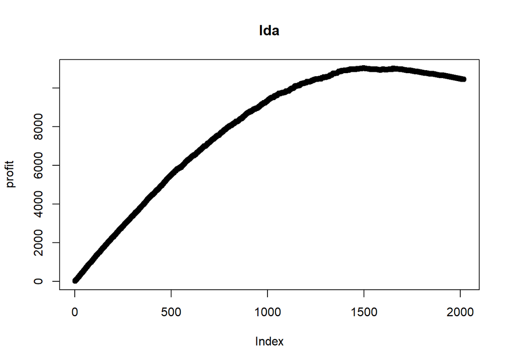

```
##                y.valid.donr
## pred.valid.donr   0   1
##               0 489  31
##               1 530 968
## Accuracy
## 0.722002
```

```
## [1] "Maximum profit earned with LDA model is:  11040"
```

```r
classify_donr<- function(modelName,Vars,k)  {

  library(caret)

  if (is.null(Vars)) {
    cl.eval.formula<-eval(parse(text= paste("donr ~.")))

  } else {
  cl.p.list<-Vars[1]

  for (i in 2:length(Vars))
    cl.p.list<- paste(cl.p.list,Vars[i],sep = "+")

  cl.eval.formula<-eval(parse(text= paste("donr ~",cl.p.list)))
  }

if (modelName == "lda") {
   library(MASS)
   model<-lda(eval(cl.eval.formula),data.train.std.donr)
   post.valid <- predict(model, data.valid.std.donr)$posterior[,2] # 2018 posterior probabilities

  } else if (modelName == "qda") {
   library(MASS)
   model<-qda(eval(cl.eval.formula),data.train.std.donr)
   post.valid <- predict(model, data.valid.std.donr)$posterior[,2] # 2018 posterior probabilities
  } else if (modelName == "logistic") {

   model<-glm(eval(cl.eval.formula),data.train.std.donr,family="binomial")
   post.valid <- predict(model, data.frame(x.valid.std), type="response") # 2018 probabilities

  } else if (modelName == "knn") {
   library(class)
   post.valid<-knn(data.train.std.donr[,Vars],data.valid.std.donr[,Vars],y.train.donr,k)

  } else if (modelName == "decision.tree") {
   library(rpart)
   model<-rpart(eval(cl.eval.formula),data.train.std.donr,method="class")
   post.valid<-predict(model,data.valid.std.donr)[,2]
  } else if (modelName == "svm") {
   library(e1071)
   model<-svm(eval(cl.eval.formula),data.train.std.donr,kernel="polynomial")
   post.valid<-predict(model,data.valid.std.donr)
  } else if (modelName == "naive.bayes") {
   library(e1071)
   model<-naiveBayes(eval(cl.eval.formula),data.train.std.donr)
   post.valid<-predict(model,data.valid.std.donr)
  } else if (modelName == "gam") {
   library(gam)
   model<-gam(donr~.,data.train.std.donr, family = "gaussian") #
   post.valid<-predict(model,data.valid.std.donr)
  } else if (modelName == "randomforest") {
   library(randomForest)
   model<-randomForest(as.factor(donr)~.,data.train.std.donr,mtry=16,ntree=500)
   post.valid<-predict(model,data.valid.std.donr)
  }
# Profit calculations using average donation = $14.50 and mailing cost = $2
profit <- cumsum(14.5*y.valid.donr[order(post.valid, decreasing=T)]-2)

plot(profit, main=modelName) # see how profits change as more mailings are made
n.mail.valid <- which.max(profit) # number of mailings that maximizes profits
c(n.mail.valid, max(profit)) # report number of mailings and maximum profit

 if (!(modelName %in% c("knn","randomforest"))) {
cutoff <- sort(post.valid, decreasing=T)[n.mail.valid+1] # set cutoff based on n.mail.valid
pred.valid.donr <- ifelse(post.valid>cutoff, 1, 0) # mail to everyone above the cutoff
class_table<-table(pred.valid.donr, y.valid.donr) # classification table
} else {
class_table<-table(post.valid, y.valid.donr) # classification table
}
print(class_table)

print(confusionMatrix(class_table,positive="1")$overall["Accuracy"])

return(max(profit))
}

# Function callls
Vars= c("reg4","home" ,"chld" ,"hinc","I(hinc^2)")
Vars2=c("reg3","reg4","home", "chld", "hinc", "genf", "incm", "plow", "npro", "rgif", "tdon", "agif")
Vars3=c("reg3","reg4","home", "chld", "hinc","I(hinc^2)", "genf", "incm", "plow", "npro", "rgif", "tdon", "agif")
paste("Maximum profit earned with LDA model is: ", classify_donr("lda",Vars2))
```

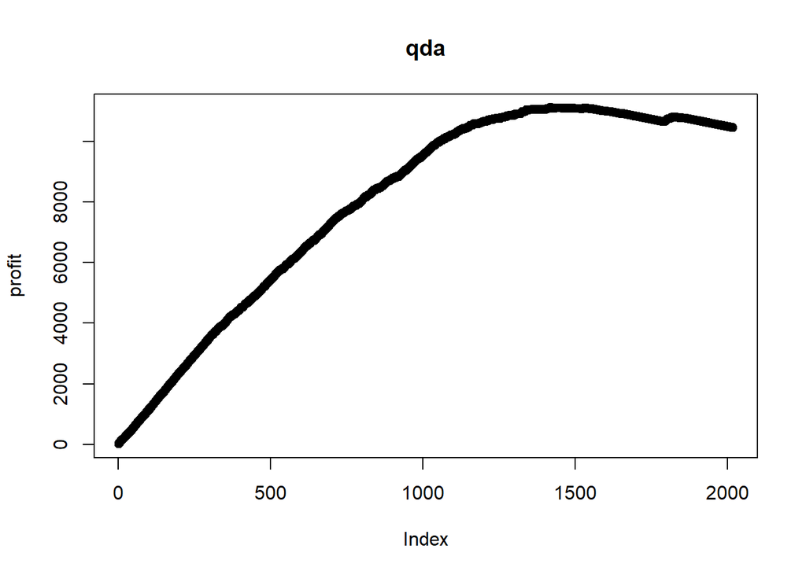

```
##                y.valid.donr
## pred.valid.donr   0   1
##               0 562  37
##               1 457 962
##  Accuracy
## 0.7552032
```

```
## [1] "Maximum profit earned with QDA model is:  11111"
```

```r
Vars1=c("reg3","reg4","home", "chld", "hinc", "genf", "incm", "plow", "npro", "rgif", "tdon")
paste("Maximum profit earned with QDA model is: ", classify_donr("qda",Vars1))
```

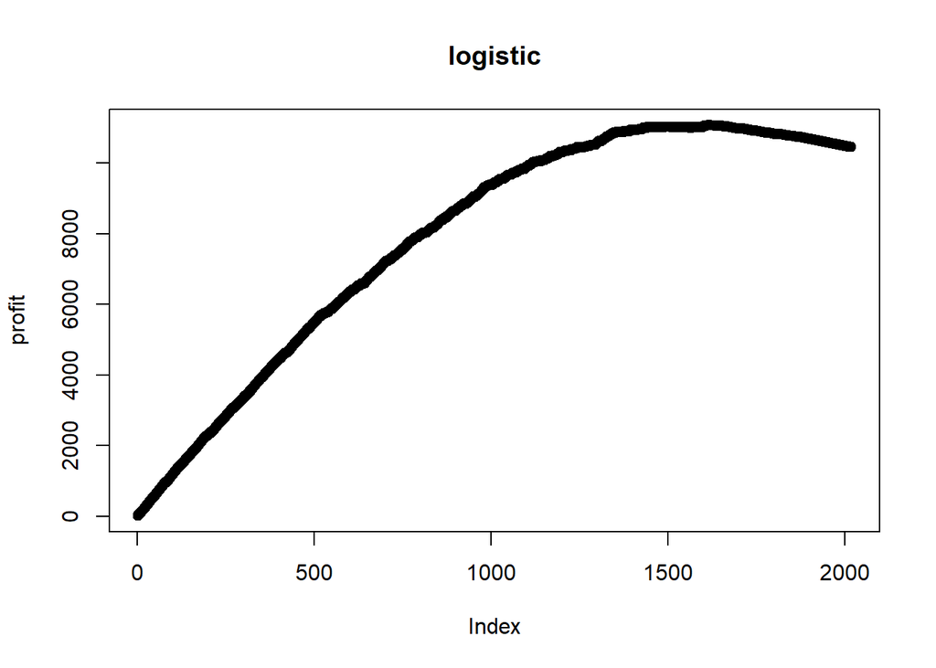

```
##                y.valid.donr
## pred.valid.donr   0   1
##               0 389  12
##               1 630 987
##  Accuracy
## 0.6818632
```

```
## [1] "Maximum profit earned with logistic model is:  11077.5"
```

```r
Vars2=c("reg3","reg4","home", "chld", "hinc", "genf", "incm", "plow", "npro", "rgif", "tdon", "agif")
paste("Maximum profit earned with logistic model is: ", classify_donr("logistic",Vars2))
```

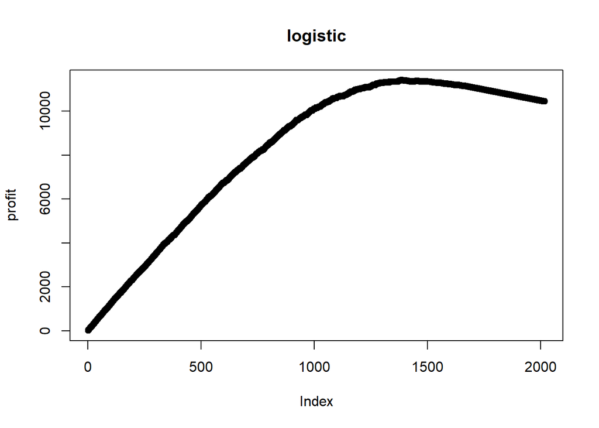

```
##                y.valid.donr
## pred.valid.donr   0   1
##               0 612  20
##               1 407 979
##  Accuracy
## 0.7884044
```

```
## [1] "Maximum profit earned with logistic model is:  11423.5"
```

```r
Vars<-NULL
paste("Maximum profit earned with logistic model is: ", classify_donr("logistic",Vars))
```

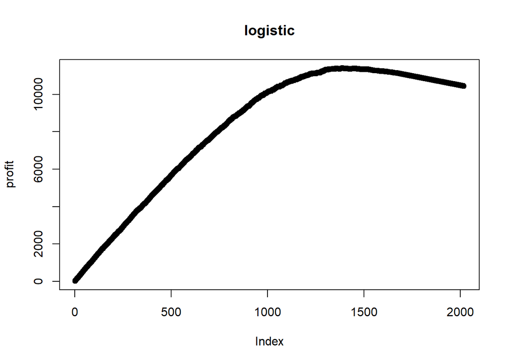

```
##                y.valid.donr
## pred.valid.donr   0   1
##               0 610  21
##               1 409 978
##  Accuracy
## 0.7869177
```

```
## [1] "Maximum profit earned with logistic model is:  11407"
```

```r
#Vars2=c("reg3","reg4","home", "chld", "hinc", "genf", "incm", "plow", "npro", "rgif", "tdon", "agif")
#paste("Maximum profit earned with logistic model is: ", classify_donr("logistic",Vars3))
Vars.lo=c("reg1","reg2","home","chld","wrat","incm","plow","npro","tgif","tdon","tlag")
paste("Maximum profit earned with logistic model is: ", classify_donr("logistic",Vars.lo))
```

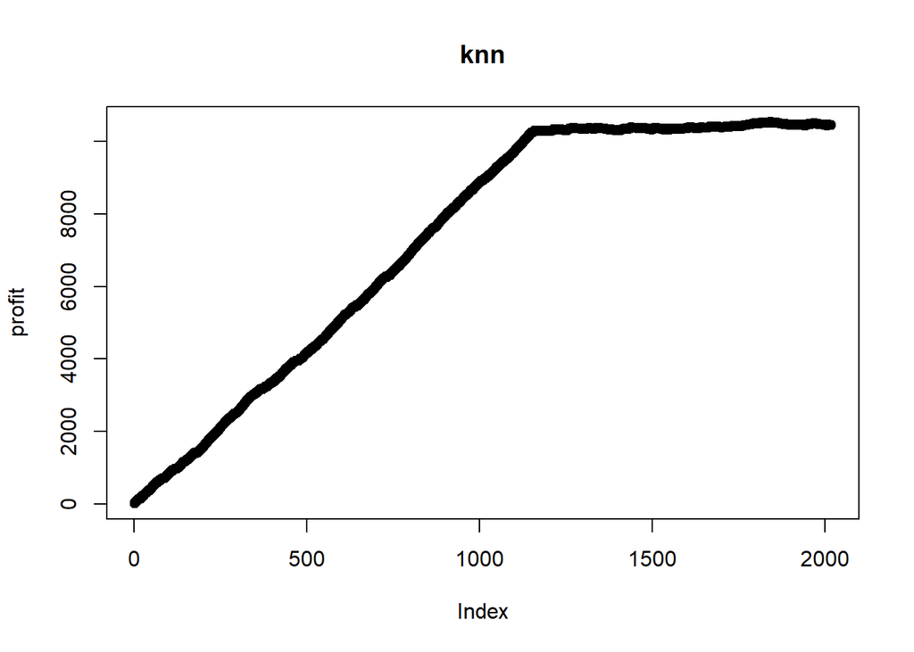

```
##           y.valid.donr
## post.valid   0   1
##          0 728 128
##          1 291 871
##  Accuracy
## 0.7923687
```

```
## [1] "Maximum profit earned with knn model is:  10538.5"
```

```r
# need to create a new column if transformation is needed.
Vars2=c("reg3","reg4","home", "chld", "hinc", "genf", "incm", "plow", "npro", "rgif", "tdon", "agif")
Vars1=c("reg3","reg4","home", "chld", "hinc", "genf", "incm", "plow", "npro", "rgif", "tdon")
paste("Maximum profit earned with knn model is: ", classify_donr("knn",Vars1,5))
```

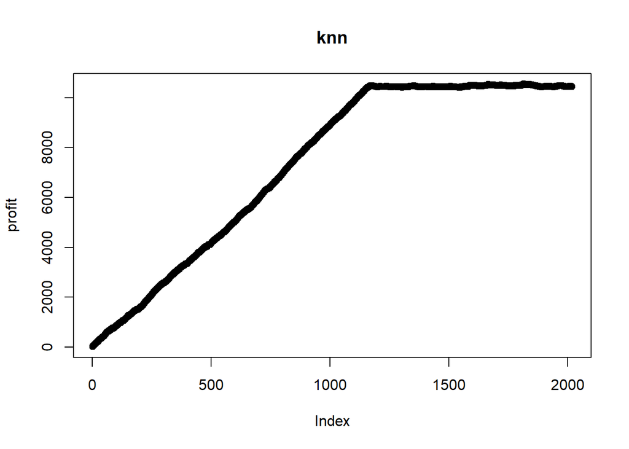

```
##           y.valid.donr
## post.valid   0   1
##          0 733 115
##          1 286 884
##  Accuracy
## 0.8012884
```

```
## [1] "Maximum profit earned with knn model is:  10549"
```

```r
paste("Maximum profit earned with knn model is: ", classify_donr("knn",Vars2,15))
```

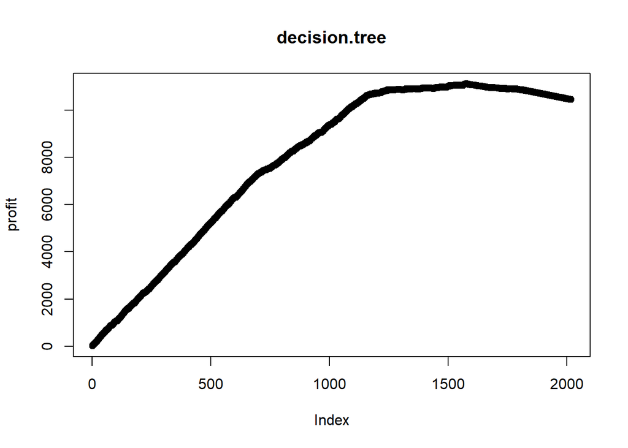

```
##                y.valid.donr
## pred.valid.donr   0   1
##               0 667  73
##               1 352 926
##  Accuracy
## 0.7893954
```

```
## [1] "Maximum profit earned with knn model is:  11116"
```

```r
paste("Maximum profit earned with knn model is: ", classify_donr("decision.tree",Vars2))
```

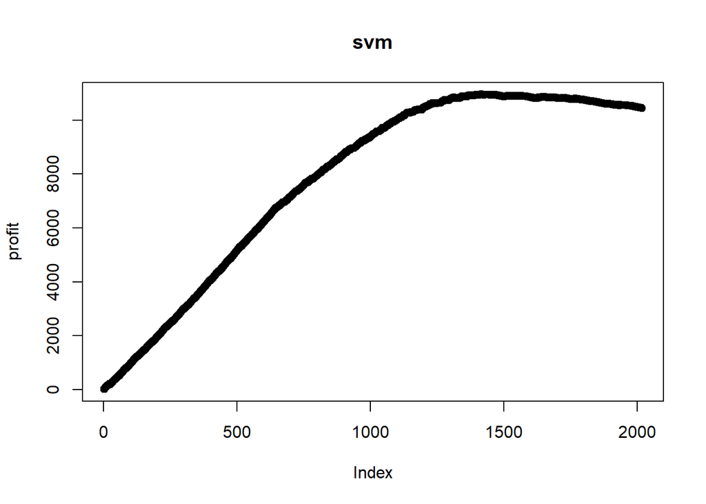

```
##                y.valid.donr
## pred.valid.donr   0   1
##               0 555  48
##               1 464 951
##  Accuracy
## 0.7462834
```

```
## [1] "Maximum profit earned with knn model is:  10959.5"
```

```r
paste("Maximum profit earned with knn model is: ", classify_donr("svm",Vars2))
```

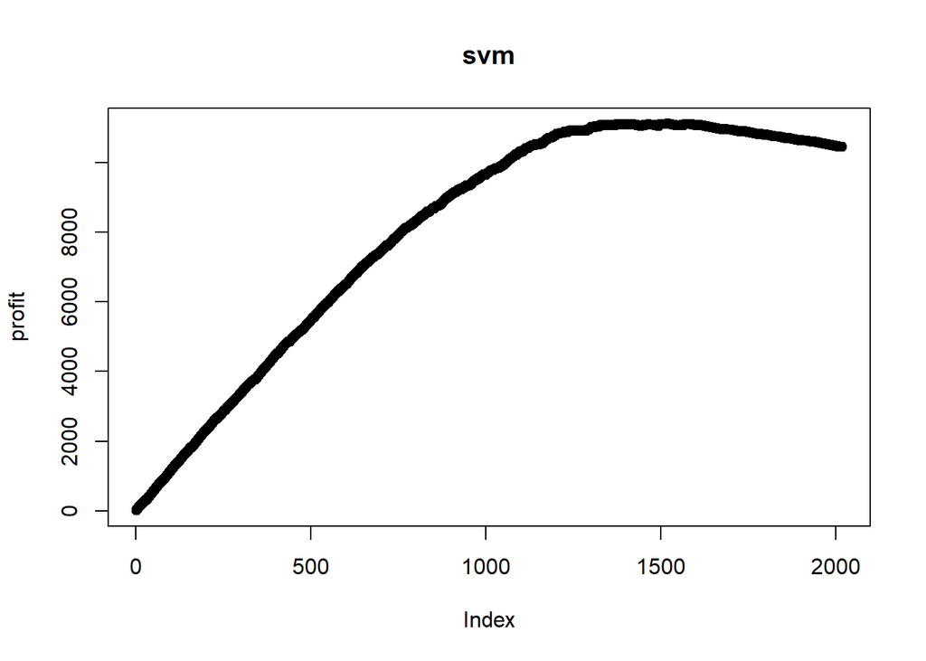

```
##                y.valid.donr
## pred.valid.donr   0   1
##               0 475  23
##               1 544 976
##  Accuracy
## 0.7190287
```

[output not shown]

```r
Vars4=c("reg4","home", "chld", "hinc","I(hinc^2)", "genf", "incm", "plow", "npro", "tdon", "agif","tgif")

# "I(sqrt(tdon))"
paste("Maximum profit earned with knn model is: ", classify_donr("svm",Vars4))
```

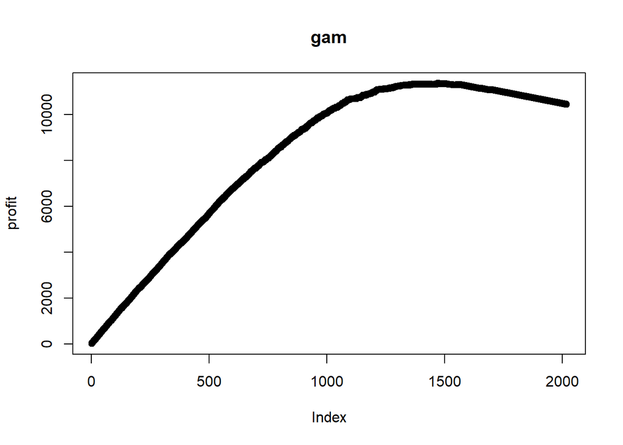

```
##                y.valid.donr
## pred.valid.donr   0   1
##               0 534  12
##               1 485 987
##  Accuracy
## 0.7537166
```

```
## [1] "Maximum profit earned with GAM model is:  11367.5"
```

```r
# data.train.std.donr$log.tgif<-log(data.train.std.donr$tgif);
# data.train.std.donr$log.agif<-log(data.train.std.donr$agif)
# data.train.std.donr$log.incm<-log(data.train.std.donr$incm)
# data.train.std.donr$sqrt.tdon<-sqrt(data.train.std.donr$tdon)


paste("Maximum profit earned with GAM model is: ", classify_donr("gam",Vars2))
```

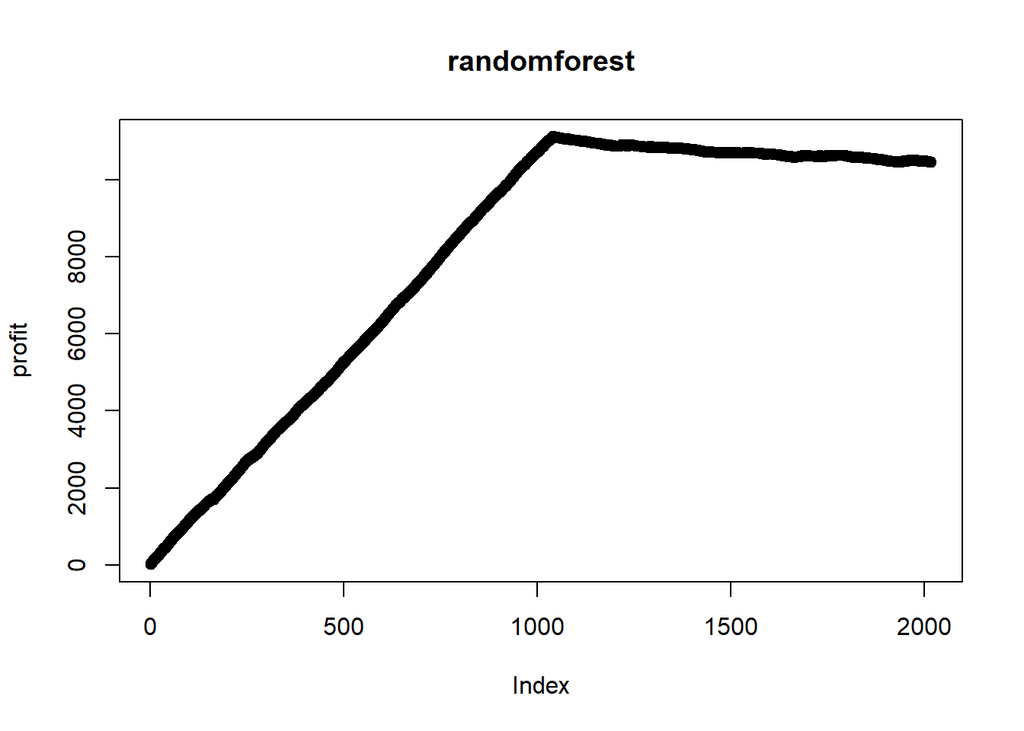

```
##           y.valid.donr
## post.valid   0   1
##          0 888  89
##          1 131 910
##  Accuracy
## 0.8909812
```

[output not shown]

```r
Vars2=c("reg3","reg4","home", "chld", "hinc", "genf", "incm", "plow", "npro", "rgif", "tdon", "agif")
# Vars2=c("reg3","reg4","home", "chld", "hinc", "genf", "incm", "plow", "npro", "rgif", "tdon", "agif","log.tgif","log.agif","log.incm","sqrt.tdon")
paste("Maximum profit earned with knn model is: ", classify_donr("randomforest",Vars2))
```